# 통계밥법론2 Chap7 실습코드

- model: 영향 진단을 하고자하는 적합된 모델
- vars: 사용할 영향 측도

`Cook.s`에서는 **Breen, Patrick**, **Reed,James**의 값이 1보다 크기 때문에 영향치로 판단하였고,  
`표준화잔차`에서도 **Breen, Patrick**, **Reed,James**이 큰 양의 잔차를 갖기 때문에 영향치로 판단하였으며, `Hat-value`에서는 **Donner, Elizabetch**, **Graves, Elizabetch C.**이 기준 값을 넘기 때문에 영향치로 판단하였다.

*Example 7.14: Death in the ICU*

```r
icu.glm2 <- glm(died ~ age + cancer + admit + uncons,
                data = ICU, family = binomial)
```

`ICU`데이터에서 **died**를 종속변수로하고 **age,cancer,admit,uncons**를 독립변수로 하는 로지스틱 회귀모형을 적합시켰다.

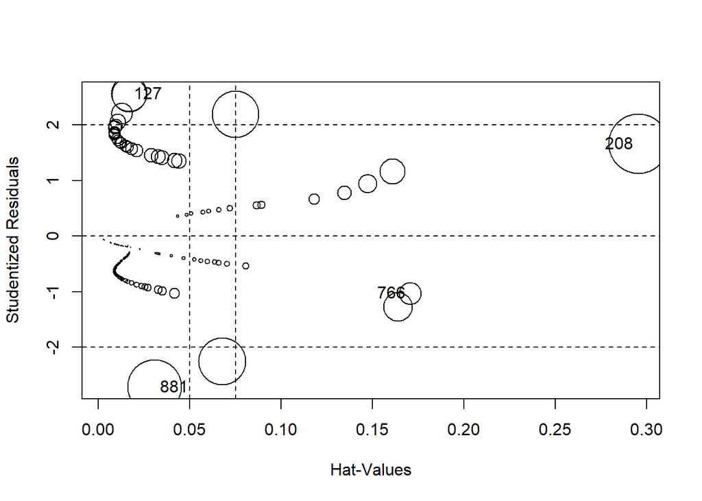

```r
library(car)
res <- influencePlot(icu.glm2, id.col = "red",
                     scale = 8, id.cex = 1.5, id.n = 3)
```

```r
idx <- which(rownames(ICU) %in% rownames(res))
cbind(ICU[idx, c("died", "age", "cancer", "admit", "uncons")],res)
```

```
##     died age cancer admit uncons   StudRes        Hat      CookD
## 766   No  31 Cancer Emerg      - -1.028188 0.17061852 0.02955116
## 881   No  89      - Emerg Uncons -2.717799 0.03080649 0.16858459
## 127  Yes  19      - Emerg      -  2.564904 0.01679238 0.07418793
## 208  Yes  70      -     - Uncons  1.661771 0.29536641 0.20870044
```

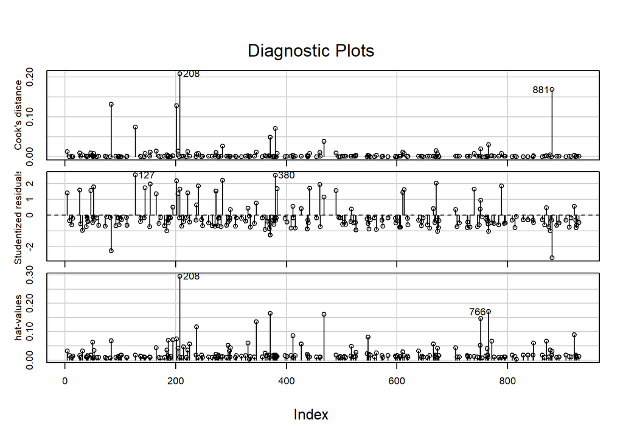

```r
influenceIndexPlot(icu.glm2, vars = c("Cook", "Studentized","hat"),id.n=4)
```

**ICU**데이터에 대해 `influencePlot`, `influenceIndexPlot`를 이용하여 극단적인 관측치 판단을 진행해 보았다.  
**127, 208, 766, 881**번 인덱스를 가지는 데이터가 극단치로 감지되었다.  
특히, 208번 데이터의 경우 **Cancer = no**, **Age**가 70세인 노인이지만 사망한 결과가 있다. 또한, 선택적 절차를 통해 입원을 했지만 의식이 없었다는 점에서 매우 이상한 것을 확인할 수 있다. 이는 코딩 오류 혹은 다른 이상 징후가 있었을지도 모른다는 신호이다.

```r
inf1 <- influence.measures(icu.glm2)
dfbetas <- data.frame(inf1$infmat[,2:5])
colnames(dfbetas) <- c("dfb.age", "dfb.cancer", "dfb.admit",
                       "dfb.uncons")
head(dfbetas)
```

```
##        dfb.age  dfb.cancer    dfb.admit  dfb.uncons
## 8   0.04733967 0.013418002  0.004066771 0.009253540
## 12  0.01898756 0.018411953 -0.004174352 0.018105763
## 14 -0.00105108 0.014882364  0.026277782 0.005555015
## 28  0.03156245 0.018424160 -0.001511499 0.016639891
## 32 -0.16408413 0.003787997 -0.036505068 0.023488029
## 38 -0.02152522 0.016539495 -0.011936576 0.020803347
```

`influence.measures`함수를 통해 각 변수들에 대한 **DFBETA**통계량을 쉽게 얻을 수 있다.

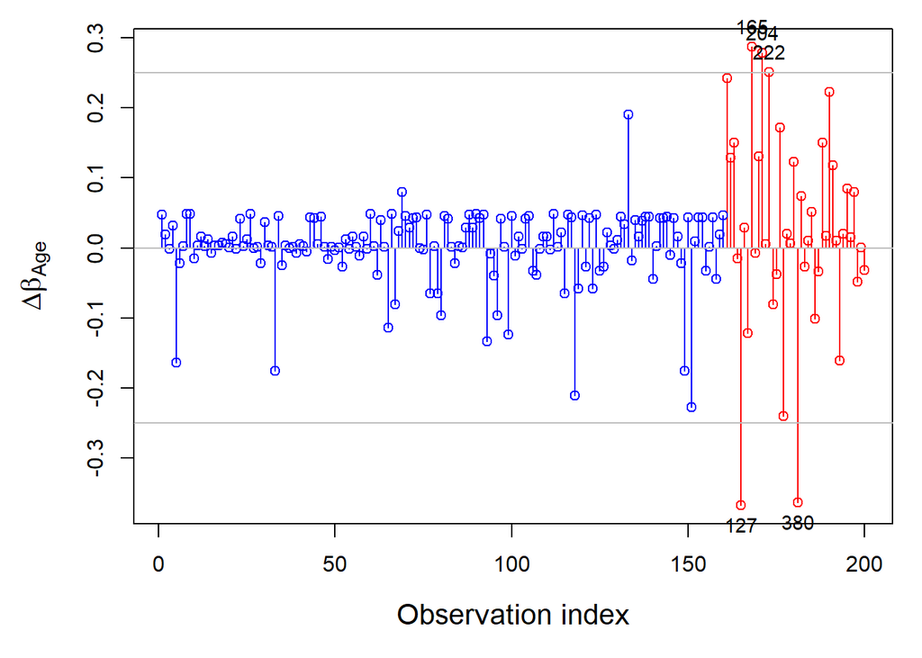

```r
op <- par(mar = c(5,5,1,1) + .1)
cols <- ifelse(ICU$died == "Yes", "red", "blue")
plot(dfbetas[,1], type = "h", col = cols,
     xlab = "Observation index",
     ylab = expression(Delta * beta[Age]),
     cex.lab = 1.3)
points(dfbetas[,1], col = cols)
big <- abs(dfbetas[,1]) > .25
idx <- 1 : nrow(dfbetas)
text(idx[big], dfbetas[big,1], label = rownames(dfbetas)[big],
     cex = 0.9, pos = ifelse(dfbetas[big,1] > 0,3,1),
     xpd = TRUE)
abline(h = c(-.25, 0, .25), col = "gray")
```

```r
par(op)
```

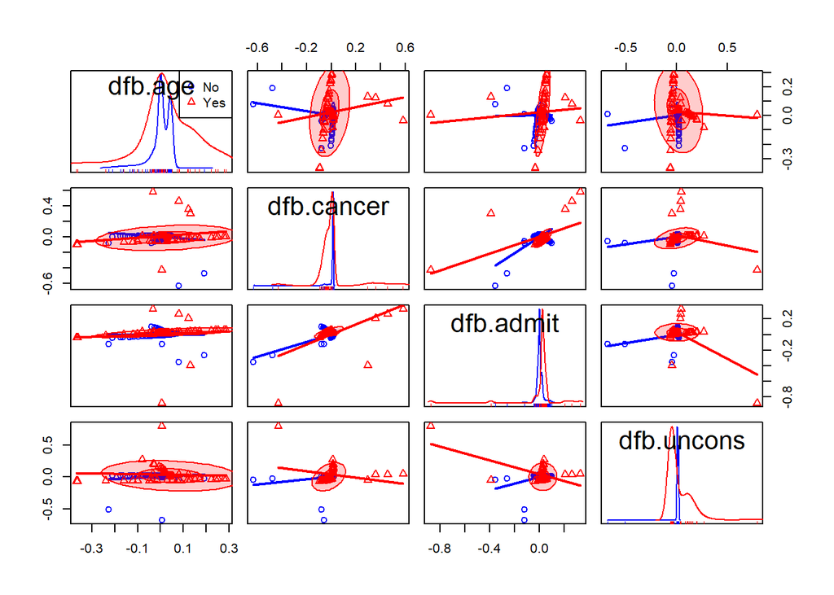

```r
scatterplotMatrix(dfbetas, smooth = FALSE, id.n = 2,
                  ellipse = TRUE, levels = 0.95, robust = FALSE,
                  diagonal = "histogram",
                  groups = ICU$died, col = c("blue","red"))
```

`scatterplotMatrix`함수를 통해 대각선의 일변량 표시와 다양한 적합선, 타원체 등 향상된 삼점도 행렬을 그릴 수 있다.  
따라서, 우리는 `scatterplotMatrix`함수를 통해 변수별 표준화된 **DFBETA**의 scatterplot을 그릴 수 있다. 각 쌍의 그림에서 비정상적인 점을 식별하며, 각 비대각 패널에서 95% 데이터 타원과 선형 회귀선은 두 측정값 사이의 한계 관계를 보여준다.  
`scatterplotMatrix`는 `car`패키지에 포함돼있다.  
- `scatterplotMatrix(x)`

- x: 산점도 행렬을 생성하고자 하는 데이터

산점도 행렬에 표시되는 색은 환자의 생존여부에 따라 구분하였다. **died = No**인 경우 파란색, **died = Yes**인 경우 빨간색으로 지정하였다.  
다른 변수들에 비해 **Age**변수의 **DFBETA**값을 가지고 있는 **dfb.age**의 경우 환자의 생존여부에 따라 분포가 큰 차이가 나는 것을 확인할 수 있다.  
이에따라, **dfb.age**와 다른 변수들간의 관계를 살펴보게 되면 **died = Yes**에 관한 타원형의 너비가 상대적으로 큰 것을 확인할 수 있다.

### 7.5.3 Other diagnostic plots

이 절에서 설명하는 그래픽 방법은 각각 주어진 방식으로 표현되는 특정 설명변수 집합을 가진 특정 모델의 적합성에 대한 간단한 지표이다.  
설명 변수 및 설명 변수의 관계가 선형인지 여부, 여기에는 **Component-plus-residual plot**, **added-variable plot**, **constructed variable plot**이 포함된다.

#### 7.5.3.1 Component-plus-residual plots

*Example 7.15: Donner Party*

```r
donner.mod1 <- glm(survived ~ age + sex,
                   data = Donner, family = binomial)
donner.mod3 <- glm(survived ~ poly(age,2) + sex,
                   data = Donner, family = binomial)
```

`donner.mod1`객체에는 **survived**를 종속변수로 하고 **age,sex**를 설명변수로하는 로지스틱 회귀모형을, `donner.mod3`객체에는 **survived**를 종속변수로 하고 **age의 2차식,sex**를 설명변수로하는 로지스틱 회귀모형을 적합시켰다.

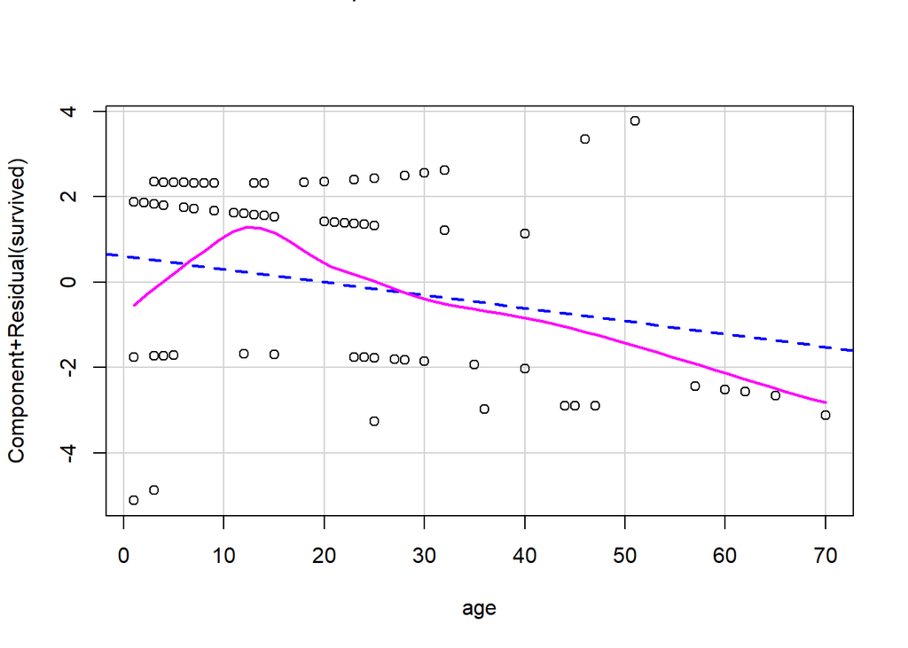

```r
crPlots(donner.mod1, ~age, id.n=2)
```

`crPlots`의 경우 선형 및 일반화된 선형 모델에 대해 **부분 잔차 그림**이라고도 하며 **성분 + 잔차**그림을 구성한다.  
`crPlots`함수는 `car`패키지안에 포함돼있다.  
- `crPlots(model,variable)`

- model: 성분+잔차 그림을 살펴보고자 하는 모델
- variable: 모델에 적합된 변수들 중 살펴보고자 하는 변수

이는 우리가 지정한 변수와 반응 변수간의 비선형 관계를 확인할 수 있다.

**파란색 파선**은 전체 모델에 대한 **Age** 기울기를 나타내고 **빨간색 곡선**은 **loess fit(비선형 곡선)**을 나타낸다.  
각 점은 각 관찰값들의 **잔차**를 표시하며 몇 개의 데이터가 극단적인 잔차값을 가지는 것을 확인할 수 있다.

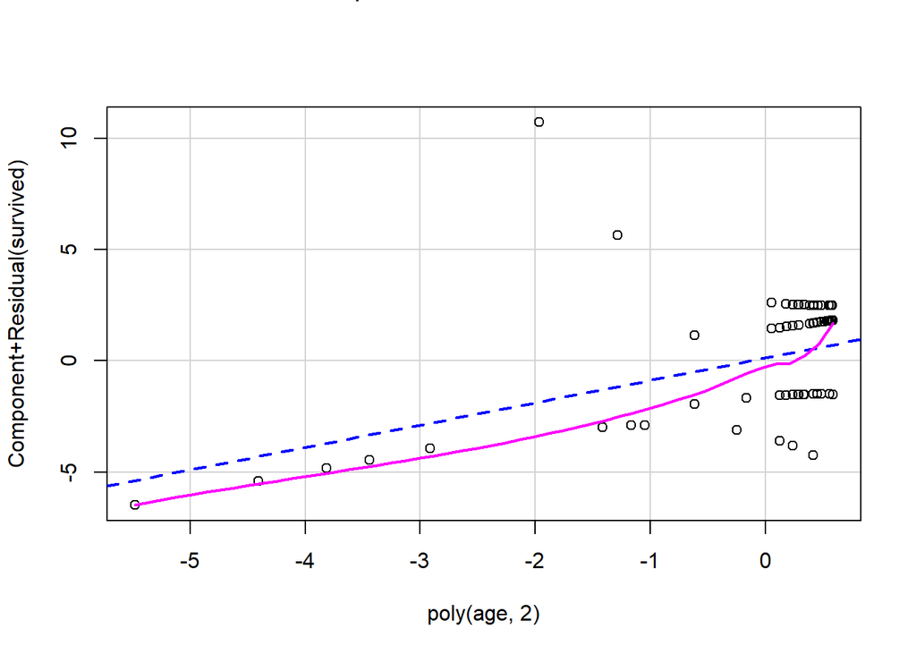

```r
crPlots(donner.mod3, ~poly(age,2), id.n=2)
```

2차식을 사용할 경우, 앞선 그림과 달리 **잔차**들이 특정 위치에 몰려있는 것을 확인할 수 있다.  
또한, 제곱을 하는 2차식을 사용했기 때문에 몇몇의 극단적인 잔차들의 값이 더욱 커진 것을 살펴볼 수 있다.

#### 7.5.3.2 Added-variable plots

*Example 7.16: Donner Party*

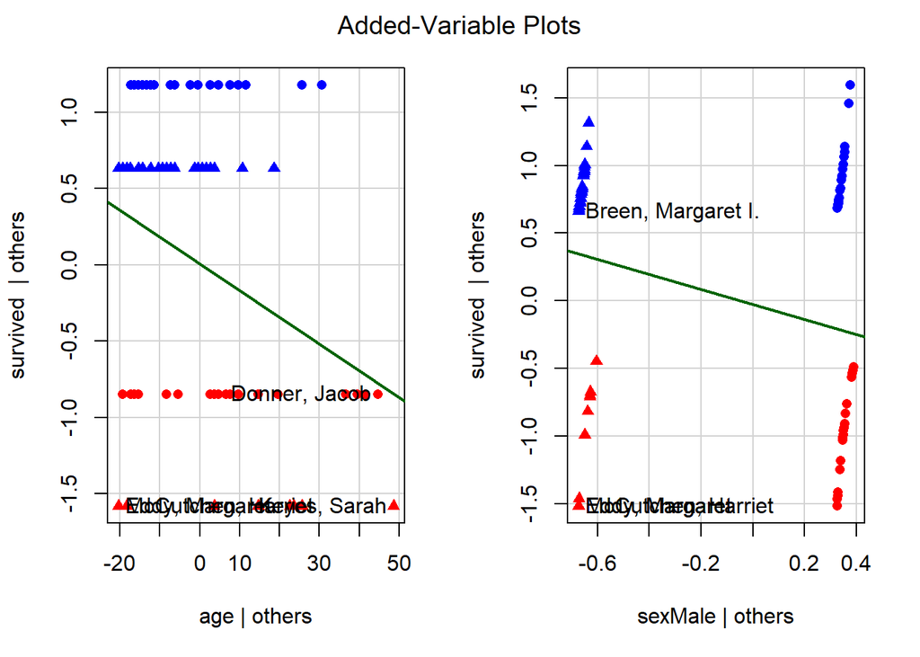

```r
col <- ifelse(Donner$survived == "yes", "blue", "red")
pch <- ifelse(Donner$sex == "Male", 16, 17)
avPlots(donner.mod1, id.n = 2,
        col = col, pch = pch, col.lines = "darkgreen")
```

`avPlots`은 로지스틱 회귀 분석 및 기타 선형 또는 일반화된 선형 모델의 문제를 진단하기 위한 또다른 중요한 도구이다. 이들은 기본적으로 조정된 반응 변수와 조정된 설명 변수에 대해 다른 모든 설명 변수 사이의 조건부 관계를 나타내는 그림이다.  
R에서는 `car` 패키지를 통해 `avPlots`함수를 사용할 수 있다.  
- `avPlots(model, id.n)`

- model: 문제를 진단하기 위한 모델
- id.n: 가장 극단적인 관측치 중 출력할 관측치의 갯수

`Donner`데이터에 대한 문제를 진단하기 위해 `avPlots`의 일부 기능을 나타낼 수 있다.

색깔의 경우, **Survived = Yes**이면 파란색, **Survived = No**이면 빨간색으로 출력하게 설정하였다.  
또한, 점의 모양의 경우 **Sex = Male**이면 원, **Sex = Female**이면 삼각형으로 그려지도록 설정하였다.

왼쪽패널은 **Age**에 대한 `avPlots`그림을 나타낸다.  
초록색 직선은 **Age**변수의 변화에 따른 생존확률의 변화를 나타내며, **Age**가 증가함에 따라 생존확률이 점차 감소한다.  
**Donner, Jacob**, **Keyes, Sarah**를 극단적인 관측치로 판단한 것을 살펴볼 수 있다.  
**Age**변수가 30세보다 큰 값을 가지게 되면 거의 모든 변수에 대해서 **Survived = No**로 분류하는 것을 확인할 수 있다.

오른쪽패널은 **Sex**에 대한 `avPlots`그림을 나타낸다.  
초록색 직선은 **Sex**변수의 변화에 따른 생존확률의 변화를 나타낸다. **Sex**가 **Male**로 변화함에 따라 생존확률이 점차 감소한다.  
**Breen, Margaret I., Pike, Harriet**을 극단적인 관측치로 판단한 것을 살펴볼 수 있다.

*Example 7.17: Death in the ICU*

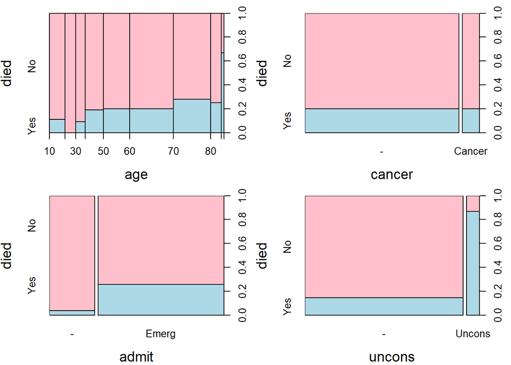

```r
op <- par(mfrow = c(2,2), mar = c(4,4,1,2.5) + .1, cex.lab = 1.4)
plot(died ~ age, data = ICU, col = c("lightblue", "pink"))
plot(died ~ cancer, data = ICU, col = c("lightblue", "pink"))
plot(died ~ admit, data = ICU, col = c("lightblue", "pink"))
plot(died ~ uncons, data = ICU, col = c("lightblue", "pink"))
```

**반응변수(died)**에 대한 각 독립변수의 `Marginal plot`을 그려보았다.  
색깔이 분홍색인 경우, **died = No**인 비율을 나타내고 색깔이 하늘색인 경우, **died = Yes**인 비율을 나타낸다.  
**age**가 높아질수록, **died = Yes**인 비율이 높았고 응급하게 병원에 입원한 경우에는 입원절차를 밟고 입원한 환자보다 **died = Yes**인 비율이 높았으며, 환자가 의식불명인 경우, 그렇지 않은 사람보다 **died = Yes**비율이 높은 것을 확인할 수 있다.

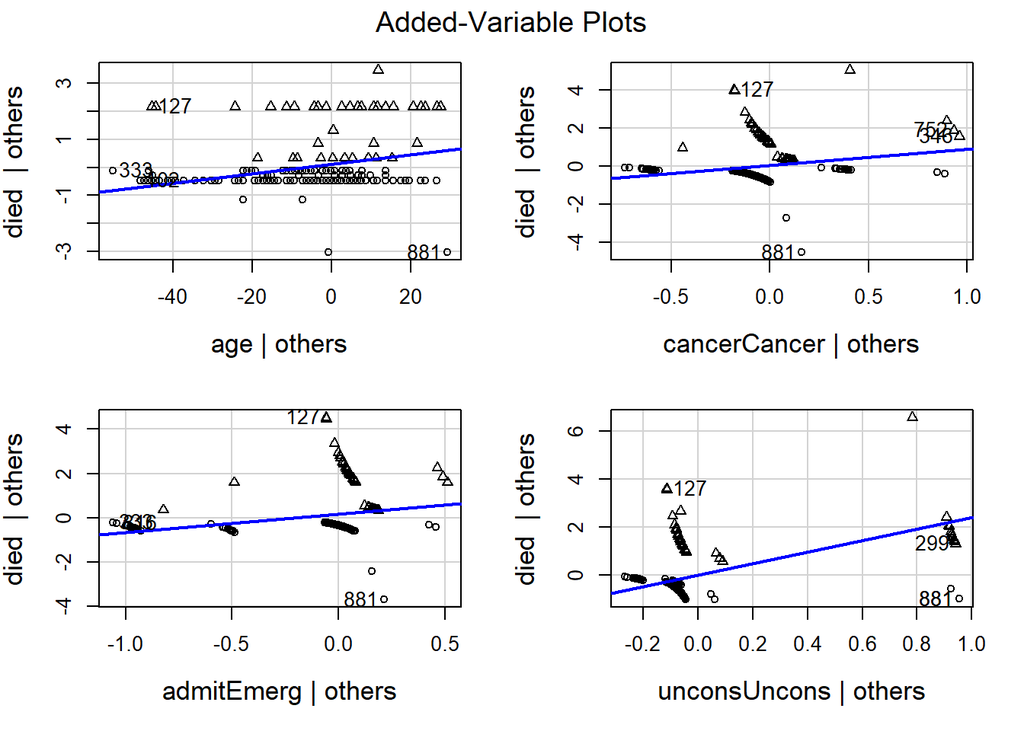

```r
pch <- ifelse(ICU$died =="No", 1,2)
avPlots(icu.glm2, id.n = 2, pch = pch, cex.lab = 1.3)
```

**died =No**인 경우, 점의 형태를 원으로하고 **died = Yes**인 경우 점의 형태를 삼각형으로 지정해주었다.  
적합시킨 로지스틱 회귀모형을 `avPlots`함수를 이용하여 추가변수 플랏을 그려보았다.

각 패널의 라벨링된 점은 다른 설명변수 1개가 주어졌을 때, 잔차가 극단적인 값을 갖는 데이터를 말한다.  
앞서, 극단적인 값으로 확인된 **127,881**번 데이터의 경우, 모든 패널에서 극단적인 값으로 인식되는 것을 확인할 수 있다.  
특히, 127번은 매우 극단적인 양의 잔차를 가지며 881번의 경우 매우 극단적인 음의 잔차를 가지는 것을 볼 수 있다.

```r
icu.glm2a <- glm(died ~ age + cancer + admit + uncons + systolic,
                 data = ICU, family = binomial)
anova(icu.glm2, icu.glm2a, test = "Chisq")
```

```
## Analysis of Deviance Table
##
## Model 1: died ~ age + cancer + admit + uncons
## Model 2: died ~ age + cancer + admit + uncons + systolic
##   Resid. Df Resid. Dev Df Deviance Pr(>Chi)
## 1       195     139.13
## 2       194     135.61  1   3.5231  0.06052 .
## ---
## Signif. codes:  0 '***' 0.001 '**' 0.01 '*' 0.05 '.' 0.1 ' ' 1
```

`glm2` 모델과 **systolic**를 추가한 `glm2a`모델이 유의한 차이가 있는지 `anova`검정을 실시해 보았다.  
두 모형의 잔차차이는 3.5231이고 유의확률은 유의수준 0.05보다 높으므로 귀무가설을 기각하지 못한다. 따라서, 유의한 잔차의 차이가 발생하지 않는 것을 확인할 수 있다.  
하지만, 유의확률이 0.06으로 유의수준인 0.05와 크게 차이가 없는 것으로 보아 약간의 유의한 잔차의 차이는 존재하는 것으로 생각된다.

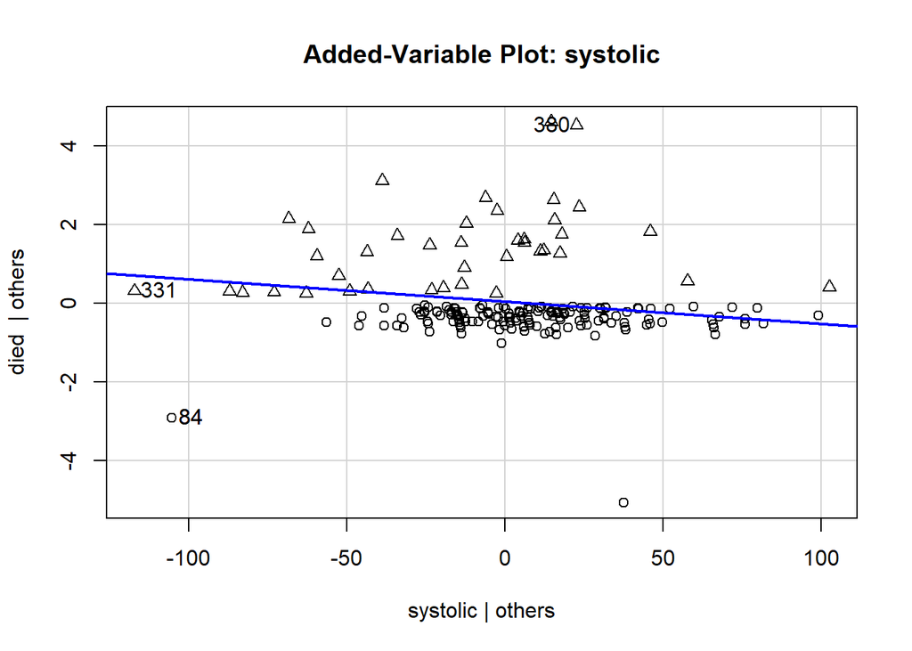

```r
avPlot(icu.glm2a, "systolic", id.n = 3, pch = pch)
```

## 7.A. Appendix

R을 통해 시각화를 진행하여 Markdown으로 생성하는 경우, 경고메시지(Warning)가 많이 뜨는 경우가 종종 있다.  
이 때, 경고메시지를 Markdown에 표시되지 않게 만들어 정리 된 Markdown을 만들고 싶다면 Chunk를 생성할 때, `{r}`이 아닌 `{r warning = FALSE}`로 만들어주면 된다.  
`{r warning = FALSE}`를 지정해주게 되면 Markdown에서 경고메시지가 사라지는 것을 확인할 수 있다.

[Reference] https://m.blog.naver.com/y4769/221851780608 https://specialscene.tistory.com/14

## Summary of Chapter7

- **로지스틱 회귀분석**은 반응변수가 연속형이 아닌 **이산형 변수**일 때, 사용된다. 일반적인 선형회귀분석은 설명변수를 통해 종속변수를 예측하는 것이 목적이지만, 로지스틱 회귀분석은 **이산형 반응변수에 대해** 0 또는 1로 분류될 확률을 예측하는 것이 목적이다.
- 일반적으로 로지스틱 회귀분석의 분류 **threshold**는 0.5의 값을 사용한다. 즉, 추정된 확률값이 0.5보다 크면 반응변수를 1로 분류하고 추정된 확률값이 0.5보다 작으면 0으로 분류한다. 이러한 **threshold**는 분석가가 데이터의 분포에 따라 정할 수 있다.
- R에서는 **로지스틱 회귀모형**을 적합시킬때에 `glm`함수를 가장 일반적으로 사용한다. `type = response(link = logit)`옵션을 통해 이산형 반응변수를 가지며, **link function**은 **logit**함수를 사용하는 로지스틱 회귀모형을 적합시킬 수 있다.
- `coeftest`는 주어진 모델의 변수에 대해 **Wald**검정을 수행하여 각 설명변수의 유의성을 판단할 수 있도록 도와준다.
- **로지스틱 회귀모형**의 적합도를 구하는 방법 중 하나는 LR방법을 통해 잔차의 차이를 계산하는 것이다. 간단한 모형과 원하는 변수를 추가시킨 모형의 잔차를 비교하여, 유의한 잔차의 차이를 보이는 경우, 원하는 변수를 추가시킨 모형은 유의하다고 할 수 있다.
- `Effects`함수와 `Allefects`함수를 사용하게 되면 변수의 수준 변화에 따른 반응변수의 확률값 변화를 시각화를 통해 나타낼 수 있다.
- `rms`패키지의 `lrm`함수는 최대우도 추정법 혹은 페널티가 부여된 최대우도 추정법을 사용하여 **비례 승산 순서형 로지스틱 회귀모형**에 적합시킨다. `lrm`을 통해 적합시킨 로지스틱 회귀모형에 `plot`함수를 사용하게 되면, 변수들의 오즈비 추정값, 추정된 오즈비의 95% 신뢰구간 등의 정보를 시각할 수 있다.
- 회귀모형을 적합한 후, 잔차진단을 통해 모형에 영향을 미치는 극단적인 관찰값이 없는지 확인하는 것이 중요하다. 이러한 측도로는 **쿡의거리, Hat-value, 잔차**등이 있으며, R에서는 추가변수를 통해 극단값을 확인하는 `avPlot`또는 성분과 잔차를 한 그림안에 나타내주는 `crPlots`함수를 사용하여 잔차진단을 할 수 있다.